# FIT5202 2026 S1 Assignment 1 : Analysing Road Safety Data

- Part 1 : Data Loading and Transformation
  - 1.1 Data Preparation and Loading
  - 1.2 Data Cleansing
- Part 2 : Working with DataFrames
  - 2.1-2.8 Query/Analysis
  - 2.9 Open Question
- Part 3 : Query Optimisation

Note: Feel free to add Code/Markdown cells as you need.

# Part 1 : Data Loading and Transformation (15%)

In this section, you need to create data frames from the given datasets, perform partitioning and use various operations to answer the queries.

## 1.1 Data Preparation and Loading

1. Write the code to create a SparkContext object using SparkSession. Use the UK (Europe/London) time as the session time zone. Give your application an appropriate name and run Spark locally with 4 cores on your machine.

```python
from pyspark.sql import SparkSession

# Initialise SparkSession with 4 local cores and UK timezone
spark = (
    SparkSession.builder
    .appName("FIT5202_A1_RoadSafetyAnalysis")
    .master("local[4]")
    .config("spark.sql.session.timeZone", "Europe/London")
    .getOrCreate()
)

# Suppress verbose INFO logs — keeps notebook output clean
spark.sparkContext.setLogLevel("WARN")

# Confirm the session is active
print(f"Spark Version     : {spark.version}")
print(f"App Name          : {spark.sparkContext.appName}")
print(f"Master            : {spark.sparkContext.master}")
print(f"Session Timezone  : {spark.conf.get('spark.sql.session.timeZone')}")
```

```
Spark Version     : 4.1.1
App Name          : FIT5202_A1_RoadSafetyAnalysis
Master            : local[4]
Session Timezone  : Europe/London
```

2. Load the CSV and JSON files into multiple data frames with an explicit StructType schema (most of the columns can use an integer, except for those with text data and latitude/longitude).

```python
import json
from pyspark.sql.types import (
    StructType, StructField,
    StringType, IntegerType, DoubleType
)
```

```python
# ── File paths ──────────────────────────────────────────────────────────────
# Adjust this base path to where your dataset folder is mounted in Docker
BASE_PATH = "/home/student/Assignment 1"   # typical Jupyter Docker mount point

COLLISION_PATH   = f"{BASE_PATH}/collision.csv"
ACCIDENTS_PATH   = f"{BASE_PATH}/accidents.csv"
VEHICLE_PATH     = f"{BASE_PATH}/vehicle.csv"
POLICE_JSON_PATH = f"{BASE_PATH}/police_force.json"
```

```python
# ── Schema: collision.csv (22 columns) ──────────────────────────────────────
collision_schema = StructType([
    StructField("collision_index",                          StringType(),  True),
    StructField("longitude",                                DoubleType(),  True),
    StructField("latitude",                                 DoubleType(),  True),
    StructField("police_force",                             IntegerType(), True),
    StructField("collision_severity",                       IntegerType(), True),
    StructField("number_of_vehicles",                       IntegerType(), True),
    StructField("number_of_casualties",                     IntegerType(), True),
    StructField("date",                                     StringType(),  True),
    StructField("time",                                     StringType(),  True),
    StructField("local_authority_district",                 IntegerType(), True),
    StructField("road_type",                                IntegerType(), True),
    StructField("speed_limit",                              IntegerType(), True),
    StructField("junction_detail",                          IntegerType(), True),
    StructField("junction_control",                         IntegerType(), True),
    StructField("pedestrian_crossing",                      IntegerType(), True),
    StructField("light_conditions",                         IntegerType(), True),
    StructField("weather_conditions",                       IntegerType(), True),
    StructField("road_surface_conditions",                  IntegerType(), True),
    StructField("special_conditions_at_site",               IntegerType(), True),
    StructField("carriageway_hazards",                      IntegerType(), True),
    StructField("urban_or_rural_area",                      IntegerType(), True),
    StructField("did_police_officer_attend_scene_of_accident", IntegerType(), True),
])
```

```python
# ── Schema: accidents.csv / casualties (12 columns) ─────────────────────────
accidents_schema = StructType([
    StructField("collision_index",         StringType(),  True),
    StructField("vehicle_reference",       IntegerType(), True),
    StructField("casualty_reference",      IntegerType(), True),
    StructField("casualty_class",          IntegerType(), True),
    StructField("sex_of_casualty",         IntegerType(), True),
    StructField("age_of_casualty",         IntegerType(), True),
    StructField("casualty_severity",       IntegerType(), True),
    StructField("pedestrian_location",     IntegerType(), True),
    StructField("pedestrian_movement",     IntegerType(), True),
    StructField("car_passenger",           IntegerType(), True),
    StructField("casualty_type",           IntegerType(), True),
    StructField("casualty_distance_banding", IntegerType(), True),
])
```

```python
# ── Schema: vehicle.csv (22 columns) ────────────────────────────────────────
vehicle_schema = StructType([
    StructField("collision_index",               StringType(),  True),
    StructField("vehicle_reference",             IntegerType(), True),
    StructField("vehicle_type",                  IntegerType(), True),
    StructField("vehicle_manoeuvre",             IntegerType(), True),
    StructField("vehicle_direction_from",        IntegerType(), True),
    StructField("vehicle_direction_to",          IntegerType(), True),
    StructField("vehicle_location_restricted_lane", IntegerType(), True),
    StructField("junction_location",             IntegerType(), True),
    StructField("skidding_and_overturning",      IntegerType(), True),
    StructField("hit_object_in_carriageway",     IntegerType(), True),
    StructField("vehicle_leaving_carriageway",   IntegerType(), True),
    StructField("hit_object_off_carriageway",    IntegerType(), True),
    StructField("first_point_of_impact",         IntegerType(), True),
    StructField("vehicle_left_hand_drive",       IntegerType(), True),
    StructField("sex_of_driver",                 IntegerType(), True),
    StructField("age_of_driver",                 IntegerType(), True),
    StructField("engine_capacity_cc",            IntegerType(), True),
    StructField("propulsion_code",               IntegerType(), True),
    StructField("age_of_vehicle",                IntegerType(), True),
    StructField("generic_make_model",            StringType(),  True),
    StructField("escooter_flag",                 IntegerType(), True),
    StructField("driver_distance_banding",       IntegerType(), True),
])
```

```python
# ── Schema: police_force.json ────────────────────────────────────────────────
# This JSON has an unusual structure — the key is a raw SQL string,
# and the value is the actual array of {id, name} records.
# PySpark's native JSON reader can't handle this, so we parse it with Python first.

police_schema = StructType([
    StructField("id",   StringType(), True),
    StructField("name", StringType(), True),
])

with open(POLICE_JSON_PATH, "r") as f:
    raw_json = json.load(f)

# Extract the list (it's the only value in the dict, regardless of the key name)
police_records = list(raw_json.values())[0]

# Create Spark DataFrame from the Python list of dicts
police_df = spark.createDataFrame(police_records, schema=police_schema)
```

```python
# ── Load CSVs ────────────────────────────────────────────────────────────────
collision_df = (
    spark.read
    .option("header", True)       # first row is column names
    .option("nullValue", "")      # treat empty strings as null
    .schema(collision_schema)
    .csv(COLLISION_PATH)
)

accidents_df = (
    spark.read
    .option("header", True)
    .option("nullValue", "")
    .schema(accidents_schema)
    .csv(ACCIDENTS_PATH)
)

vehicle_df = (
    spark.read
    .option("header", True)
    .option("nullValue", "")
    .schema(vehicle_schema)
    .csv(VEHICLE_PATH)
)

print("All DataFrames loaded successfully.")
```

```
All DataFrames loaded successfully.
```

3. Display the total row count and the first 5 records of the collision, accident and vehicle.

```python
# ── Row Counts ───────────────────────────────────────────────────────────────
print("=" * 60)
print(f"collision_df  row count : {collision_df.count():,}")
print(f"accidents_df  row count : {accidents_df.count():,}")
print(f"vehicle_df    row count : {vehicle_df.count():,}")
print(f"police_df     row count : {police_df.count():,}")
print("=" * 60)
```

```
============================================================
collision_df  row count : 8,703,911
accidents_df  row count : 11,577,521
vehicle_df    row count : 15,532,272
police_df     row count : 52
============================================================
```

```python
# ── First 5 Records: collision_df ────────────────────────────────────────────
print("collision_df — First 5 Records:")
collision_df.show(5, truncate=False)
```

```
collision_df — First 5 Records:
+---------------+---------+---------+------------+------------------+------------------+--------------------+----------+-----+------------------------+---------+-----------+---------------+----------------+-------------------+----------------+------------------+-----------------------+--------------…
|collision_index|longitude|latitude |police_force|collision_severity|number_of_vehicles|number_of_casualties|date      |time |local_authority_district|road_type|speed_limit|junction_detail|junction_control|pedestrian_crossing|light_conditions|weather_conditions|road_surface_conditions|special_condit…
+---------------+---------+---------+------------+------------------+------------------+--------------------+----------+-----+------------------------+---------+-----------+---------------+----------------+-------------------+----------------+------------------+-----------------------+--------------…
|2018450290294  |-0.746206|51.08897 |45          |3                 |2                 |2                   |15/04/2018|08:00|517                     |6        |30         |0              |-1              |0                  |1               |9                 |1                      |0             …
|2020230984311  |-1.511123|52.2213  |23          |2                 |5                 |2                   |21/09/2020|23:00|293                     |3        |70         |0              |-1              |0                  |6               |1                 |1                      |4             …
|1998929800391  |NULL     |NULL     |92          |3                 |1                 |1                   |29/01/1998|11:00|910                     |6        |30         |0              |-1              |0                  |1               |1                 |1                      |0             …
|1996950661096  |NULL     |NULL     |95          |3                 |2                 |2                   |01/07/1996|16:20|923                     |6        |30         |16             |4               |0                  |1               |1                 |1                      |0             …
|2006620156303  |-3.439174|51.709038|62          |3                 |2                 |1                   |01/09/2006|14:15|744                     |6        |30         |13             |4               |0                  |1               |1                 |1                      |0             …
+---------------+---------+---------+------------+------------------+------------------+--------------------+----------+-----+------------------------+---------+-----------+---------------+----------------+-------------------+----------------+------------------+-----------------------+--------------…
only showing top 5 rows
```

```python
# ── First 5 Records: accidents_df ────────────────────────────────────────────
print("accidents_df — First 5 Records:")
accidents_df.show(5, truncate=False)
```

```
accidents_df — First 5 Records:
+---------------+-----------------+------------------+--------------+---------------+---------------+-----------------+-------------------+-------------------+-------------+-------------+-------------------------+
|collision_index|vehicle_reference|casualty_reference|casualty_class|sex_of_casualty|age_of_casualty|casualty_severity|pedestrian_location|pedestrian_movement|car_passenger|casualty_type|casualty_distance_banding|
+---------------+-----------------+------------------+--------------+---------------+---------------+-----------------+-------------------+-------------------+-------------+-------------+-------------------------+
|197905H200700  |1                |1                 |1             |1              |20             |3                |0                  |0                  |0            |109          |-1                       |
|197952FKE0696  |1                |1                 |2             |2              |18             |3                |0                  |0                  |1            |109          |-1                       |
|197997NC01901  |2                |1                 |2             |1              |65             |3                |0                  |0                  |1            |109          |-1                       |
|1979316110883  |1                |1                 |2             |1              |52             |3                |0                  |0                  |2            |109          |-1                       |
|197901F9MCD21  |1                |1                 |2             |1              |87             |3                |0                  |0                  |0            |11           |-1                       |
+---------------+-----------------+------------------+--------------+---------------+---------------+-----------------+-------------------+-------------------+-------------+-------------+-------------------------+
only showing top 5 rows
```

```python
# ── First 5 Records: vehicle_df ──────────────────────────────────────────────
print("vehicle_df — First 5 Records:")
vehicle_df.show(5, truncate=False)
```

```
vehicle_df — First 5 Records:
+---------------+-----------------+------------+-----------------+----------------------+--------------------+--------------------------------+-----------------+------------------------+-------------------------+---------------------------+--------------------------+---------------------+-----------…
|collision_index|vehicle_reference|vehicle_type|vehicle_manoeuvre|vehicle_direction_from|vehicle_direction_to|vehicle_location_restricted_lane|junction_location|skidding_and_overturning|hit_object_in_carriageway|vehicle_leaving_carriageway|hit_object_off_carriageway|first_point_of_impact|vehicle_lef…
+---------------+-----------------+------------+-----------------+----------------------+--------------------+--------------------------------+-----------------+------------------------+-------------------------+---------------------------+--------------------------+---------------------+-----------…
|2014214000919  |2                |9           |19               |1                     |5                   |0                               |8                |0                       |0                        |0                          |0                         |1                    |1          …
|2014554C16552  |2                |9           |9                |7                     |5                   |0                               |8                |0                       |0                        |0                          |0                         |3                    |1          …
|201442I094703  |4                |9           |3                |7                     |3                   |0                               |5                |0                       |0                        |0                          |0                         |2                    |1          …
|201443W158124  |1                |9           |19               |6                     |2                   |0                               |0                |0                       |0                        |0                          |0                         |1                    |1          …
|201406L082426  |2                |9           |19               |8                     |4                   |0                               |8                |0                       |0                        |0                          |0                         |4                    |1          …
+---------------+-----------------+------------+-----------------+----------------------+--------------------+--------------------------------+-----------------+------------------------+-------------------------+---------------------------+--------------------------+---------------------+-----------…
only showing top 5 rows
```

### 1.2 Data Cleansing

Real-world data is messy. You must filter out anomalies and invalid entries before analysis, please perform the following data cleansing tasks.

1. Handle Missing/Invalid Values(2%): Filter the DataFrames to remove any records where key IDs are null and where did_police_officer_attend_scene_of_accident contains the missing data code -1.

```python
from pyspark.sql.functions import col

# ── Before counts ─────────────────────────────────────────────────────────────
print("Row counts BEFORE cleansing:")
print(f"  collision_df : {collision_df.count():,}")
print(f"  accidents_df : {accidents_df.count():,}")
print(f"  vehicle_df   : {vehicle_df.count():,}")
print()

# ── collision_df ──────────────────────────────────────────────────────────────
# Drop rows where the primary key is null
# Drop rows where police attendance field contains the missing data code -1
collision_df = collision_df.filter(
    col("collision_index").isNotNull() &
    (col("did_police_officer_attend_scene_of_accident") != -1)
)

# ── accidents_df ──────────────────────────────────────────────────────────────
# Drop rows where either part of the composite key is null
accidents_df = accidents_df.filter(
    col("collision_index").isNotNull() &
    col("casualty_reference").isNotNull()
)

# ── vehicle_df ────────────────────────────────────────────────────────────────
# Drop rows where either part of the composite key is null
vehicle_df = vehicle_df.filter(
    col("collision_index").isNotNull() &
    col("vehicle_reference").isNotNull()
)

# ── After counts ──────────────────────────────────────────────────────────────
print("Row counts AFTER missing/invalid value cleansing:")
print(f"  collision_df : {collision_df.count():,}")
print(f"  accidents_df : {accidents_df.count():,}")
print(f"  vehicle_df   : {vehicle_df.count():,}")
```

```
Row counts BEFORE cleansing:
  collision_df : 8,703,911
  accidents_df : 11,577,521
  vehicle_df   : 15,532,272

Row counts AFTER missing/invalid value cleansing:
  collision_df : 3,727,110
  accidents_df : 11,577,521
  vehicle_df   : 15,532,272
```

2. Spatial Bounding Box(2%): The UK has specific geographical bounds. Filter the collision DataFrame to remove any geospatial outliers (accidents that mistakenly plot outside the UK or have missing coordinates). Keep only records where:  
   • latitude is between 49.0 and 61.0  
   • longitude is between -9.0 and 2.0  
   Instead of hardcoding those values, create a reusable UDF function called isUK to perform the filtering.

```python
from pyspark.sql.functions import udf
from pyspark.sql.types import BooleanType

# ── Define the isUK UDF ───────────────────────────────────────────────────────
# Returns True only if coordinates are non-null AND within UK bounds
# Returns False for NULLs or out-of-bounds values — those rows get dropped

def isUK(latitude, longitude):
    if latitude is None or longitude is None:
        return False
    return (49.0 <= latitude <= 61.0) and (-9.0 <= longitude <= 2.0)

isUK_udf = udf(isUK, BooleanType())

# ── Apply UDF to filter collision_df ─────────────────────────────────────────
print(f"collision_df before spatial filter : {collision_df.count():,}")

collision_df = collision_df.filter(
    isUK_udf(col("latitude"), col("longitude"))
)

print(f"collision_df after spatial filter  : {collision_df.count():,}")
```

```
collision_df before spatial filter : 3,727,110
collision_df after spatial filter  : 3,724,768
```

3. Perform the following subtasks:  
   a) Check and print the number of partitions for the data frames.

```python
# ── Partition counts after cleansing ─────────────────────────────────────────
print("Partition counts after cleansing:")
print(f"  collision_df : {collision_df.rdd.getNumPartitions()}")
print(f"  accidents_df : {accidents_df.rdd.getNumPartitions()}")
print(f"  vehicle_df   : {vehicle_df.rdd.getNumPartitions()}")
print(f"  police_df    : {police_df.rdd.getNumPartitions()}")
```

```
Partition counts after cleansing:
  collision_df : 6
  accidents_df : 4
  vehicle_df   : 9
  police_df    : 4
```

b) Explain how PySpark determines the default number of partitions when reading a CSV file from a local file system.

When reading a CSV file from a **local file system**, PySpark determines the default number of partitions through the following logic:

1. **File Size ÷ Block Size**: Spark divides the total file size by its default block size (128 MB). Each block becomes one partition. For example, a 512 MB CSV file would produce approximately 4 partitions.
2. **spark.default.parallelism floor**: In `local[4]` mode, `spark.default.parallelism` is set to 4 (matching the number of cores). If the file-based calculation produces fewer partitions than this value, Spark will use `spark.default.parallelism` as the minimum via `spark.sql.files.minPartitionNum`.
3. **Local vs. HDFS difference**: On a local filesystem, Spark cannot perform true distributed block splitting (unlike HDFS which stores blocks across nodes). Instead, it uses `FileInputFormat` to logically split the file into equal-sized chunks based on the configured split size (`spark.sql.files.maxPartitionBytes`, default 128 MB).

In summary, for a local CSV, the partition count ≈ max(number of cores, ceil(file size / 128 MB)).

c) If we plan to run heavy aggregations grouping by year, month and weather conditions, what strategies should we use to partition our data?

```python
from pyspark.sql.functions import to_date, year, month

# ── Step 1: Add year and month columns first (needed for partitioning) ────────
# We parse the date string here for partitioning purposes
# This will be done properly again in Part 2 Task 1 with full output

collision_df = collision_df.withColumn(
    "date_parsed", to_date(col("date"), "dd/MM/yyyy")
).withColumn(
    "year", year(col("date_parsed")).cast("integer")
).withColumn(
    "month", month(col("date_parsed")).cast("integer")
)

# ── Step 2: Repartition by aggregation keys ───────────────────────────────────
# Repartitioning by year, month and weather_conditions means rows sharing
# these key values land in the same partition — avoiding full shuffles
# during groupBy operations downstream.
# 8 partitions = 2x our core count, giving good parallelism without overhead.

collision_df = collision_df.repartition(8, "year", "month", "weather_conditions")

print(f"collision_df partitions after repartitioning : {collision_df.rdd.getNumPartitions()}")
```

```
collision_df partitions after repartitioning : 8
```

### Partitioning Strategy for Year/Month/Weather Aggregations

When running heavy aggregations grouped by `year`, `month`, and `weather_conditions`, the optimal strategy involves two complementary techniques:

1. **Repartition by grouping keys** (`repartition(n, "year", "month", "weather_conditions")`): This physically co-locates rows with identical key combinations in the same partition. When Spark executes a `groupBy` on these columns, it finds the relevant data already local to each partition — dramatically reducing shuffle volume.
2. **Choosing partition count**: A general rule is 2× the number of available cores (i.e., 8 for our `local[4]` setup). Too few partitions underutilise cores; too many creates scheduling overhead. For very large datasets you can also consider `spark.sql.shuffle.partitions` (default 200) which controls post-shuffle partitions.
3. **Alternative — partitionBy on write**: If writing the cleaned data to disk for repeated use, `df.write.partitionBy("year", "month", "weather_conditions")` creates a directory-based partition structure. Subsequent reads with filters on these columns trigger **partition pruning** — Spark only reads the relevant subdirectories, skipping irrelevant data entirely without scanning the full dataset.

The combination of repartition (for in-memory processing) and partitionBy on write (for disk-based reuse) gives the best performance for aggregation-heavy workflows.

## Part 2. Working with DataFrames (50%)

In this section, you need to use DataFrame functions to answer the queries.  
Implement the following queries using dataframes. You need to be able to perform operations like transforming, filtering, sorting, joining and groupBy using the functions provided by the DataFrame API. For each task, display the first 5 results where no output is specified. (Tasks 1-8 are 5% each, task 9 is 10%).

1. The date column is currently a String (DD/MM/YYYY). Using native PySpark functions, convert this column into a proper PySpark DateType. Then, extract the Year and Month into two new integer columns: year and month. Show the first 5 rows of these specific columns.

```python
# ── Part 2 Task 1: Date Conversion and Year/Month Extraction ─────────────────
# The date column arrives as a DD/MM/YYYY string. to_date() converts it to a
# proper PySpark DateType. year() and month() then extract integer components.
# Note: year/month were provisionally created in Part 1.3c for partitioning.
# Here they are re-derived from the properly typed DateType column, and the
# intermediate date_parsed column is removed.
from pyspark.sql.functions import to_date, year, month, col

# Convert the string date column to DateType (overwrites the string column)
collision_df = collision_df.withColumn("date", to_date(col("date"), "dd/MM/yyyy"))

# Re-derive year and month from the properly typed DateType column
# and clean up the intermediate date_parsed column from Part 1.3c
collision_df = (
    collision_df
    .withColumn("year",  year(col("date")))
    .withColumn("month", month(col("date")))
    .drop("date_parsed")
)

# Show the three relevant columns to verify the conversion
collision_df.select("date", "year", "month").show(5, truncate=False)
```

```
+----------+----+-----+
|date      |year|month|
+----------+----+-----+
|2011-06-05|2011|6    |
|2013-01-23|2013|1    |
|2012-10-07|2012|10   |
|2007-07-09|2007|7    |
|2021-05-22|2021|5    |
+----------+----+-----+
only showing top 5 rows
```

2. Perform a join between the collision data frame and the police_force ID mapping, and add the string name of the police force to your collision data frame.

```python
# ── Part 2 Task 2: Police Force Join ─────────────────────────────────────────
# police_df.id is StringType, collision_df.police_force is IntegerType.
# Cast police_force to String before joining to ensure type compatibility.
# Left join preserves all collision records even if a police_force ID
# has no matching entry in the lookup table.

from pyspark.sql.functions import col

collision_df = collision_df.join(
    police_df,
    collision_df["police_force"].cast("string") == police_df["id"],
    how="left"
).drop("id").withColumnRenamed("name", "police_force_name")

collision_df.select("collision_index", "police_force", "police_force_name").show(5, truncate=False)
```

```
+---------------+------------+-------------------+
|collision_index|police_force|police_force_name  |
+---------------+------------+-------------------+
|2011370225611  |37          |Suffolk            |
|2013471300464  |47          |Sussex             |
|2012130434564  |13          |West Yorkshire     |
|200701QK65006  |1           |Metropolitan Police|
|2021461048771  |46          |Kent               |
+---------------+------------+-------------------+
only showing top 5 rows
```

3. Filter the collision data frame to isolate incidents that occurred during "darkness" (using light_conditions) AND while it was "raining or snowing" (weather_conditions). Calculate the ratio of severe/fatal collisions to slight collisions under these exact conditions and compare it to the same ratio during clear daylight.

```python
# ── Part 2 Task 3: Darkness + Rain/Snow Risk Ratio ───────────────────────────
# Explicitly grab Python's built-in round() before PySpark overrides it
from builtins import round as py_round

from pyspark.sql.functions import col, count, when, sum as spark_sum

# ── Darkness + Rain/Snow filter ───────────────────────────────────────────────
darkness_rain_df = collision_df.filter(
    col("light_conditions").isin(4, 5, 6, 7) &
    col("weather_conditions").isin(2, 3, 5, 6)
)

# ── Clear daylight filter ─────────────────────────────────────────────────────
daylight_clear_df = collision_df.filter(
    (col("light_conditions") == 1) &
    (col("weather_conditions") == 1)
)

# ── Compute counts for darkness + rain/snow ───────────────────────────────────
darkness_rain_counts = darkness_rain_df.agg(
    spark_sum(when(col("collision_severity").isin(1, 2), 1).otherwise(0))
        .alias("severe_fatal_count"),
    spark_sum(when(col("collision_severity") == 3, 1).otherwise(0))
        .alias("slight_count"),
    count("*").alias("total_collisions")
).collect()[0]

# ── Compute counts for clear daylight ────────────────────────────────────────
daylight_counts = daylight_clear_df.agg(
    spark_sum(when(col("collision_severity").isin(1, 2), 1).otherwise(0))
        .alias("severe_fatal_count"),
    spark_sum(when(col("collision_severity") == 3, 1).otherwise(0))
        .alias("slight_count"),
    count("*").alias("total_collisions")
).collect()[0]

# ── Calculate ratios using Python's built-in round() ─────────────────────────
dr_severe = darkness_rain_counts["severe_fatal_count"]
dr_slight = darkness_rain_counts["slight_count"]
dr_ratio  = py_round(dr_severe / dr_slight, 4) if dr_slight > 0 else None

dl_severe = daylight_counts["severe_fatal_count"]
dl_slight = daylight_counts["slight_count"]
dl_ratio  = py_round(dl_severe / dl_slight, 4) if dl_slight > 0 else None

# ── Print results ─────────────────────────────────────────────────────────────
print("=" * 60)
print("Condition: Darkness + Raining or Snowing")
print(f"  Total collisions    : {dr_severe + dr_slight:,}")
print(f"  Fatal/Serious count : {dr_severe:,}")
print(f"  Slight count        : {dr_slight:,}")
print(f"  Severity ratio      : {dr_ratio}")
print()
print("Condition: Clear Daylight")
print(f"  Total collisions    : {dl_severe + dl_slight:,}")
print(f"  Fatal/Serious count : {dl_severe:,}")
print(f"  Slight count        : {dl_slight:,}")
print(f"  Severity ratio      : {dl_ratio}")
print()
print(f"Darkness+Rain/Snow is {py_round(dr_ratio/dl_ratio, 2)}x more severe than Clear Daylight")
print("=" * 60)
```

```
============================================================
Condition: Darkness + Raining or Snowing
  Total collisions    : 214,136
  Fatal/Serious count : 36,119
  Slight count        : 178,017
  Severity ratio      : 0.2029

Condition: Clear Daylight
  Total collisions    : 2,248,253
  Fatal/Serious count : 343,088
  Slight count        : 1,905,165
  Severity ratio      : 0.1801

Darkness+Rain/Snow is 1.13x more severe than Clear Daylight
============================================================
```

4. Use the vehicle data frame to find young drivers (aged 17-21) driving small-engine cars (engine_capacity_cc <= 1600). What are the top 3 most common vehicle_manoeuvre types for this demographic that resulted in the vehicle leaving the carriageway (vehicle_leaving_carriageway not equal to 0)?

```python
# ── Part 2 Task 4: Young Driver Behaviour ────────────────────────────────────
# Young drivers: age_of_driver between 17-21
# Small-engine cars: vehicle_type in (9, 109) AND engine_capacity_cc <= 1600
# Left carriageway: vehicle_leaving_carriageway != 0 (0 = did not leave)
# vehicle_manoeuvre codes mapped to string labels from metadata

from pyspark.sql.functions import col, when

# ── Manoeuvre code to label mapping (from metadata) ──────────────────────────
manoeuvre_label = (
    when(col("vehicle_manoeuvre") == 1,  "Reversing")
    .when(col("vehicle_manoeuvre") == 2,  "Parked")
    .when(col("vehicle_manoeuvre") == 3,  "Waiting to go ahead")
    .when(col("vehicle_manoeuvre") == 4,  "Slowing or stopping")
    .when(col("vehicle_manoeuvre") == 5,  "Moving off")
    .when(col("vehicle_manoeuvre") == 6,  "U-turn")
    .when(col("vehicle_manoeuvre") == 7,  "Turning left")
    .when(col("vehicle_manoeuvre") == 8,  "Waiting to turn left")
    .when(col("vehicle_manoeuvre") == 9,  "Turning right")
    .when(col("vehicle_manoeuvre") == 10, "Waiting to turn right")
    .when(col("vehicle_manoeuvre") == 11, "Changing lane to left")
    .when(col("vehicle_manoeuvre") == 12, "Changing lane to right")
    .when(col("vehicle_manoeuvre") == 13, "Overtaking moving vehicle on its offside")
    .when(col("vehicle_manoeuvre") == 14, "Overtaking stationary vehicle on its offside")
    .when(col("vehicle_manoeuvre") == 15, "Overtaking on nearside")
    .when(col("vehicle_manoeuvre") == 19, "Going ahead")
    .when(col("vehicle_manoeuvre") == 20, "Parking")
    .when(col("vehicle_manoeuvre") == 99, "Unknown")
    .otherwise("Data missing or out of range")
)

# ── Filter: young drivers in small-engine cars that left the carriageway ──────
young_driver_df = (
    vehicle_df
    .filter(
        col("vehicle_type").isin(9, 109) &              # Car types only
        col("age_of_driver").between(17, 21) &          # Young drivers
        (col("engine_capacity_cc") <= 1600) &           # Small engine
        (col("vehicle_leaving_carriageway") != 0)       # Left carriageway
    )
    .withColumn("manoeuvre_name", manoeuvre_label)
)

# ── Top 3 most common manoeuvres ──────────────────────────────────────────────
top3_manoeuvres = (
    young_driver_df
    .groupBy("vehicle_manoeuvre", "manoeuvre_name")
    .count()
    .orderBy(col("count").desc())
    .limit(3)
)

top3_manoeuvres.show(truncate=False)
```

```
+-----------------+----------------------------------------+------+
|vehicle_manoeuvre|manoeuvre_name                          |count |
+-----------------+----------------------------------------+------+
|19               |Going ahead                             |270722|
|9                |Turning right                           |16491 |
|13               |Overtaking moving vehicle on its offside|13742 |
+-----------------+----------------------------------------+------+
```

5. Join the accidents (casualties) table with the vehicle table to identify which specific vehicle_type (by string name) is statistically most likely to be involved when a pedestrian (casualty_class = 3) is fatally injured.

```python
# ── Part 2 Task 5: Pedestrian Fatalities by Vehicle Type ─────────────────────
# casualty_class = 3 → Pedestrian
# casualty_severity = 1 → Fatal
# Join on both collision_index AND vehicle_reference to correctly link
# each casualty to the exact vehicle involved — not all vehicles in collision

from pyspark.sql.functions import col, when, count

# ── Vehicle type code to label mapping (from metadata) ───────────────────────
vehicle_type_label = (
    when(col("vehicle_type") == 1,   "Pedal cycle")
    .when(col("vehicle_type") == 2,  "Motorcycle 50cc and under")
    .when(col("vehicle_type") == 3,  "Motorcycle 125cc and under")
    .when(col("vehicle_type") == 4,  "Motorcycle over 125cc and up to 500cc")
    .when(col("vehicle_type") == 5,  "Motorcycle over 500cc")
    .when(col("vehicle_type") == 8,  "Taxi/Private hire car")
    .when(col("vehicle_type") == 9,  "Car")
    .when(col("vehicle_type") == 10, "Minibus (8 - 16 passenger seats)")
    .when(col("vehicle_type") == 11, "Bus or coach (17 or more pass seats)")
    .when(col("vehicle_type") == 16, "Ridden horse")
    .when(col("vehicle_type") == 17, "Agricultural vehicle")
    .when(col("vehicle_type") == 18, "Tram")
    .when(col("vehicle_type") == 19, "Van / Goods 3.5 tonnes mgw or under")
    .when(col("vehicle_type") == 20, "Goods over 3.5t. and under 7.5t")
    .when(col("vehicle_type") == 21, "Goods 7.5 tonnes mgw and over")
    .when(col("vehicle_type") == 22, "Mobility scooter")
    .when(col("vehicle_type") == 23, "Electric motorcycle")
    .when(col("vehicle_type") == 90, "Other vehicle")
    .when(col("vehicle_type") == 97, "Motorcycle - unknown cc")
    .when(col("vehicle_type") == 98, "Goods vehicle - unknown weight")
    .when(col("vehicle_type") == 99, "Unknown vehicle type")
    .when(col("vehicle_type") == 103, "Motorcycle - Scooter (1979-1998)")
    .when(col("vehicle_type") == 104, "Motorcycle (1979-1998)")
    .when(col("vehicle_type") == 105, "Motorcycle - Combination (1979-1998)")
    .when(col("vehicle_type") == 106, "Motorcycle over 125cc (1999-2004)")
    .when(col("vehicle_type") == 108, "Taxi (excluding private hire cars) (1979-2004)")
    .when(col("vehicle_type") == 109, "Car (including private hire cars) (1979-2004)")
    .when(col("vehicle_type") == 110, "Minibus/Motor caravan (1979-1998)")
    .when(col("vehicle_type") == 113, "Goods over 3.5 tonnes (1979-1998)")
    .otherwise("Data missing or out of range")
)

# ── Filter: fatal pedestrian casualties ──────────────────────────────────────
fatal_pedestrians_df = accidents_df.filter(
    (col("casualty_class") == 3) &       # Pedestrian
    (col("casualty_severity") == 1)      # Fatal
)

# ── Join to vehicle_df on collision_index AND vehicle_reference ───────────────
fatal_ped_vehicle_df = fatal_pedestrians_df.join(
    vehicle_df,
    on=["collision_index", "vehicle_reference"],
    how="inner"
).withColumn("vehicle_type_name", vehicle_type_label)

# ── Count and rank by vehicle type ───────────────────────────────────────────
vehicle_type_counts = (
    fatal_ped_vehicle_df
    .groupBy("vehicle_type", "vehicle_type_name")
    .agg(count("*").alias("fatal_pedestrian_count"))
    .orderBy(col("fatal_pedestrian_count").desc())
)

vehicle_type_counts.show(5, truncate=False)
```

```
+------------+---------------------------------------------+----------------------+
|vehicle_type|vehicle_type_name                            |fatal_pedestrian_count|
+------------+---------------------------------------------+----------------------+
|109         |Car (including private hire cars) (1979-2004)|24635                 |
|9           |Car                                          |5266                  |
|19          |Van / Goods 3.5 tonnes mgw or under          |3199                  |
|113         |Goods over 3.5 tonnes (1979-1998)            |2647                  |
|11          |Bus or coach (17 or more pass seats)         |2370                  |
+------------+---------------------------------------------+----------------------+
only showing top 5 rows
```

6. Join tables and perform aggregations: add two columns to the collision dataframe: number_of_vehicles, number_of_casualties. Identify multi-vehicle collisions (3 or more vehicles) and compare the average age of the driver in the initiating vehicle (vehicle_reference = 1) versus the driver in the last vehicle to be struck (vehicle_reference = maximum for that specific collision_index).

```python
# ── Part 2 Task 6: Collision Dynamics and Driver Age Comparison ───────────────
from pyspark.sql.functions import col, count, max as spark_max, avg

# ── Step 1: Compute vehicle counts per collision ──────────────────────────────
vehicle_counts = (
    vehicle_df
    .groupBy("collision_index")
    .agg(count("*").alias("number_of_vehicles"))
)

# ── Step 2: Compute casualty counts per collision ─────────────────────────────
casualty_counts = (
    accidents_df
    .groupBy("collision_index")
    .agg(count("*").alias("number_of_casualties"))
)

# ── Step 3: Add computed columns to collision_df ──────────────────────────────
collision_enriched_df = (
    collision_df
    .drop("number_of_vehicles", "number_of_casualties")
    .join(vehicle_counts,  on="collision_index", how="left")
    .join(casualty_counts, on="collision_index", how="left")
)

# ── Step 4: Filter multi-vehicle collisions (3+ vehicles) ────────────────────
multi_vehicle_df = collision_enriched_df.filter(
    col("number_of_vehicles") >= 3
)

print(f"Multi-vehicle collisions (3+ vehicles): {multi_vehicle_df.count():,}")

# ── Step 5: Initiating vehicle (vehicle_reference = 1) ───────────────────────
initiating_vehicle_df = (
    vehicle_df
    .filter(col("vehicle_reference") == 1)
    .select("collision_index", col("age_of_driver").alias("initiating_driver_age"))
)

# ── Step 6: Last vehicle struck (max vehicle_reference per collision) ─────────
# Alias both DataFrames to resolve ambiguous column references
max_ref_per_collision = (
    vehicle_df
    .groupBy("collision_index")
    .agg(spark_max("vehicle_reference").alias("max_vehicle_ref"))
)

v_aliased   = vehicle_df.alias("v")
max_aliased = max_ref_per_collision.alias("m")

last_vehicle_df = (
    v_aliased
    .join(
        max_aliased,
        (col("v.collision_index") == col("m.collision_index")) &
        (col("v.vehicle_reference") == col("m.max_vehicle_ref")),
        how="inner"
    )
    .select(
        col("v.collision_index"),
        col("v.age_of_driver").alias("last_driver_age")
    )
)

# ── Step 7: Join to multi-vehicle collisions ──────────────────────────────────
age_comparison_df = (
    multi_vehicle_df
    .select("collision_index")
    .join(initiating_vehicle_df, on="collision_index", how="left")
    .join(last_vehicle_df,       on="collision_index", how="left")
)

# ── Step 8: Compute average ages — exclude -1 (missing data code) ─────────────
avg_ages = age_comparison_df.filter(
    (col("initiating_driver_age") != -1) &
    (col("last_driver_age") != -1)
).agg(
    avg("initiating_driver_age").alias("avg_initiating_driver_age"),
    avg("last_driver_age").alias("avg_last_driver_age")
).collect()[0]

# ── Step 9: Display results ───────────────────────────────────────────────────
print("=" * 60)
print("Multi-vehicle Collision Driver Age Comparison")
print(f"  Avg age — initiating vehicle (ref=1)    : "
      f"{avg_ages['avg_initiating_driver_age']:.2f}")
print(f"  Avg age — last vehicle struck (ref=max) : "
      f"{avg_ages['avg_last_driver_age']:.2f}")
print("=" * 60)

# Show first 5 rows of enriched collision_df with new computed columns
collision_enriched_df.select(
    "collision_index",
    "number_of_vehicles",
    "number_of_casualties"
).show(5, truncate=False)
```

```
Multi-vehicle collisions (3+ vehicles): 383,387
============================================================
Multi-vehicle Collision Driver Age Comparison
  Avg age — initiating vehicle (ref=1)    : 38.72
  Avg age — last vehicle struck (ref=max) : 40.80
============================================================
+---------------+------------------+--------------------+
|collision_index|number_of_vehicles|number_of_casualties|
+---------------+------------------+--------------------+
|200132C113301  |1                 |1                   |
|20014200B0432  |2                 |1                   |
|2005610019305  |2                 |1                   |
|2006070601186  |2                 |2                   |
|2006620156303  |2                 |1                   |
+---------------+------------------+--------------------+
only showing top 5 rows
```

7. Group the data to find the total number of collisions for each police_force and road_type. Print the highest road_type for each police_force.

```python
# ── Part 2 Task 7: Collisions by Police Force and Road Type ──────────────────
# Group by police_force and road_type to get total collisions
# Use window function to rank road types within each police force
# and select the highest occurring road type per force

# ── Part 2 Task 7: Collisions by Police Force and Road Type ──────────────────
from pyspark.sql.functions import col, count, when, dense_rank
from pyspark.sql.window import Window

# ── Road type code to label mapping (from metadata) ──────────────────────────
road_type_label = (
    when(col("road_type") == 1,  "Roundabout")
    .when(col("road_type") == 2,  "One way street")
    .when(col("road_type") == 3,  "Dual carriageway")
    .when(col("road_type") == 6,  "Single carriageway")
    .when(col("road_type") == 7,  "Slip road")
    .when(col("road_type") == 9,  "Unknown")
    .when(col("road_type") == 12, "One way street/Slip road")
    .when(col("road_type") == -1, "Data missing or out of range")
    .otherwise("Other")
)

# ── Step 1: Group by police_force and road_type ───────────────────────────────
collision_by_force_road = (
    collision_df
    .withColumn("road_type_name", road_type_label)
    .groupBy("police_force", "police_force_name", "road_type", "road_type_name")
    .agg(count("*").alias("total_collisions"))
)

# ── Step 2: Rank road types within each police force by collision count ────────
window_spec = Window.partitionBy("police_force").orderBy(
    col("total_collisions").desc()
)

ranked_df = collision_by_force_road.withColumn(
    "rank", dense_rank().over(window_spec)
)

# ── Step 3: Filter rank = 1 to get highest road type per police force ─────────
top_road_per_force = (
    ranked_df
    .filter(col("rank") == 1)
    .select(
        "police_force",
        "police_force_name",
        "road_type",
        "road_type_name",
        "total_collisions"
    )
    .orderBy(col("total_collisions").desc())
)

top_road_per_force.show(5, truncate=False)
```

```
+------------+-------------------+---------+------------------+----------------+
|police_force|police_force_name  |road_type|road_type_name    |total_collisions|
+------------+-------------------+---------+------------------+----------------+
|1           |Metropolitan Police|6        |Single carriageway|462104          |
|20          |West Midlands      |6        |Single carriageway|115756          |
|13          |West Yorkshire     |6        |Single carriageway|109905          |
|6           |Greater Manchester |6        |Single carriageway|106538          |
|43          |Thames Valley      |6        |Single carriageway|92751           |
+------------+-------------------+---------+------------------+----------------+
only showing top 5 rows
```

8. Group collisions by local_authority_district, and create a custom "Danger Index" for each district calculated as: (Count of Fatal * 5) + (Count of Serious * 3) + (Count of Slight * 1) / Total Collisions, print the top 10 most dangerous districts.

```python
# ── Part 2 Task 8: Danger Index by Local Authority District ──────────────────
# Danger Index = ((Fatal*5) + (Serious*3) + (Slight*1)) / Total Collisions
# collision_severity: 1=Fatal, 2=Serious, 3=Slight
# Higher index = district with proportionally more severe/fatal collisions

from pyspark.sql.functions import (
    col, count, when, sum as spark_sum
)

# ── Compute per-district severity counts and danger index ─────────────────────
danger_index_df = (
    collision_df
    .groupBy("local_authority_district")
    .agg(
        spark_sum(when(col("collision_severity") == 1, 1).otherwise(0))
            .alias("fatal_count"),
        spark_sum(when(col("collision_severity") == 2, 1).otherwise(0))
            .alias("serious_count"),
        spark_sum(when(col("collision_severity") == 3, 1).otherwise(0))
            .alias("slight_count"),
        count("*").alias("total_collisions")
    )
    .withColumn(
        "danger_index",
        (
            (col("fatal_count")   * 5) +
            (col("serious_count") * 3) +
            (col("slight_count")  * 1)
        ) / col("total_collisions")
    )
)

# ── Top 10 most dangerous districts ──────────────────────────────────────────
top10_dangerous = (
    danger_index_df
    .orderBy(col("danger_index").desc())
    .limit(10)
)

top10_dangerous.show(truncate=False)
```

```
+------------------------+-----------+-------------+------------+----------------+------------------+
|local_authority_district|fatal_count|serious_count|slight_count|total_collisions|danger_index      |
+------------------------+-----------+-------------+------------+----------------+------------------+
|911                     |466        |2703         |7253        |10422           |1.6975628478219151|
|185                     |132        |1168         |2810        |4110            |1.6968369829683698|
|934                     |268        |1821         |4820        |6909            |1.6822984512954118|
|913                     |197        |1389         |3811        |5397            |1.6607374467296647|
|385                     |199        |1256         |3553        |5008            |1.6605431309904153|
|381                     |199        |1175         |3430        |4804            |1.654870940882598 |
|930                     |120        |667          |2109        |2896            |1.6263812154696133|
|184                     |103        |974          |2742        |3819            |1.61796281749149  |
|939                     |133        |1256         |3554        |4943            |1.6158203520129475|
|181                     |183        |1472         |4367        |6022            |1.6104284290933244|
+------------------------+-----------+-------------+------------+----------------+------------------+
```

### 2.9 Open Questions

(Open Question) Explore the dataset freely and plot two diagrams of your choice. Which attributes are highly correlated with the number and severity of accident casualties? Discuss the steps of your exploration and the results. (No word limit, please keep concise.)

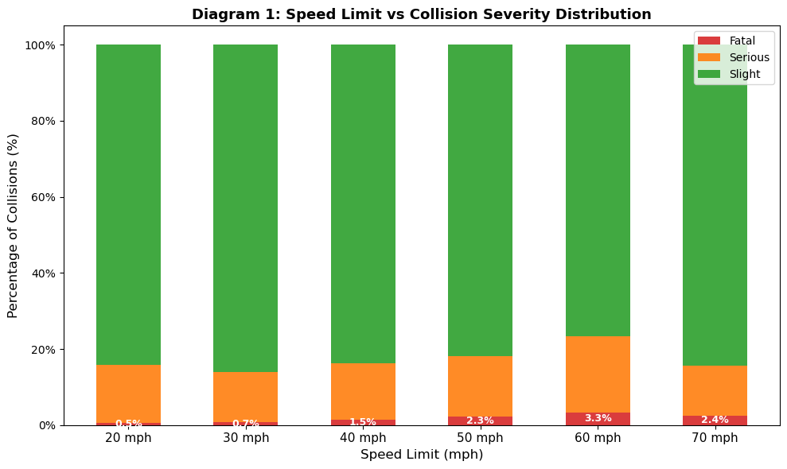

```python
# ── Part 2 Task 9 — Diagram 1: Speed Limit vs Collision Severity ──────────────
# Speed limit is a strong predictor of collision severity.
# Valid speed limits: 20, 30, 40, 50, 60, 70 mph (from metadata)
# Filter out -1 (missing) and 99 (unknown self-reported)

import matplotlib.pyplot as plt
import matplotlib.ticker as mticker
import numpy as np
from pyspark.sql.functions import col, count, when, sum as spark_sum, split

# ── Aggregate severity counts by speed limit ──────────────────────────────────
speed_severity_df = (
    collision_df
    .filter(col("speed_limit").isin(20, 30, 40, 50, 60, 70))
    .groupBy("speed_limit")
    .agg(
        spark_sum(when(col("collision_severity") == 1, 1).otherwise(0))
            .alias("fatal"),
        spark_sum(when(col("collision_severity") == 2, 1).otherwise(0))
            .alias("serious"),
        spark_sum(when(col("collision_severity") == 3, 1).otherwise(0))
            .alias("slight"),
        count("*").alias("total")
    )
    .orderBy("speed_limit")
    .toPandas()
)

# Compute percentage breakdown per speed limit
speed_severity_df["pct_fatal"]   = (speed_severity_df["fatal"]   / speed_severity_df["total"]) * 100
speed_severity_df["pct_serious"] = (speed_severity_df["serious"] / speed_severity_df["total"]) * 100
speed_severity_df["pct_slight"]  = (speed_severity_df["slight"]  / speed_severity_df["total"]) * 100

# ── Plot ──────────────────────────────────────────────────────────────────────
fig, ax1 = plt.subplots(figsize=(10, 6))

x     = np.arange(len(speed_severity_df))
width = 0.55

ax1.bar(x, speed_severity_df["pct_fatal"],
        width, label="Fatal",   color="#d62728", alpha=0.9)
ax1.bar(x, speed_severity_df["pct_serious"],
        width, bottom=speed_severity_df["pct_fatal"],
        label="Serious", color="#ff7f0e", alpha=0.9)
ax1.bar(x, speed_severity_df["pct_slight"],
        width,
        bottom=speed_severity_df["pct_fatal"] + speed_severity_df["pct_serious"],
        label="Slight",  color="#2ca02c", alpha=0.9)

# Annotate fatal % inside each bar
for i, row in speed_severity_df.iterrows():
    ax1.text(i, row["pct_fatal"] / 2,
             f"{row['pct_fatal']:.1f}%",
             ha="center", va="center",
             fontsize=9, color="white", fontweight="bold")

ax1.set_xticks(x)
ax1.set_xticklabels([f"{s} mph" for s in speed_severity_df["speed_limit"]], fontsize=11)
ax1.set_xlabel("Speed Limit (mph)", fontsize=12)
ax1.set_ylabel("Percentage of Collisions (%)", fontsize=12)
ax1.set_title("Diagram 1: Speed Limit vs Collision Severity Distribution",
              fontsize=13, fontweight="bold")
ax1.legend(loc="upper right", fontsize=10)
ax1.yaxis.set_major_formatter(mticker.PercentFormatter())

plt.tight_layout()
plt.savefig("task9_diagram1.png", dpi=150, bbox_inches="tight")
plt.show()
```

### Diagram 1: Speed Limit vs Collision Severity Distribution

Speed limit shows a strong positive correlation with collision severity across most of the range. Fatal collisions as a proportion of total collisions rise consistently from 0.5% at 20 mph zones up to a peak of 3.3% at 60 mph roads — a more than sixfold increase. Serious collisions follow a similar pattern, with 60 mph roads showing the highest combined fatal and serious proportion.

Notably, 70 mph roads buck this trend — showing lower fatal (2.4%) and serious proportions than 60 mph roads. This is explained by road type: 70 mph limits apply predominantly to motorways, which are purpose-engineered for high-speed travel with central reservation barriers, controlled access, no pedestrians, and no opposing traffic. In contrast, 60 mph limits typically apply to undivided rural single carriageways where head-on collisions and roadside hazards are far more prevalent.

This finding highlights that speed limit alone is an incomplete predictor of severity — road design and environment are critical confounding factors. The most dangerous roads by severity ratio are rural 60 mph carriageways, not motorways.

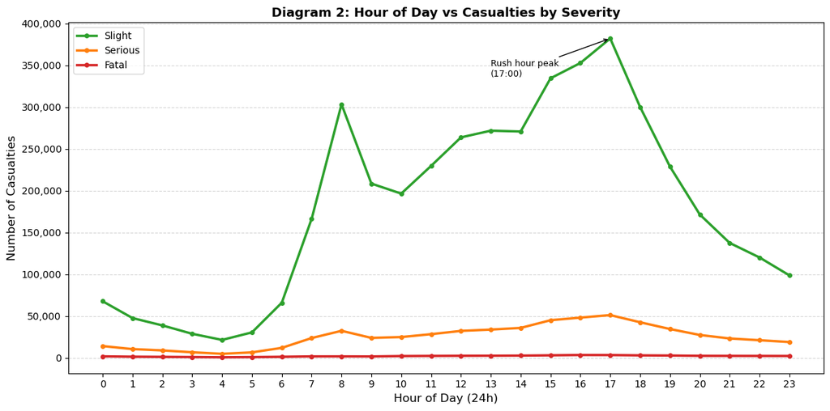

```python
# ── Part 2 Task 9 — Diagram 2: Hour of Day vs Casualties by Severity ──────────
# Time of day affects both traffic volume and driver behaviour.
# Extract hour from the time column (HH:MM format) using split.
# Join collision_df with accidents_df to get casualty severity per hour.

from pyspark.sql.functions import col, count, when, sum as spark_sum, split

# ── Aggregate casualty severity counts by hour ────────────────────────────────
hourly_df = (
    collision_df
    .withColumn("hour_of_day", split(col("time"), ":")[0].cast("integer"))
    .filter(col("hour_of_day").isNotNull())
    .join(accidents_df, on="collision_index", how="inner")
    .groupBy("hour_of_day")
    .agg(
        spark_sum(when(col("casualty_severity") == 1, 1).otherwise(0))
            .alias("fatal_casualties"),
        spark_sum(when(col("casualty_severity") == 2, 1).otherwise(0))
            .alias("serious_casualties"),
        spark_sum(when(col("casualty_severity") == 3, 1).otherwise(0))
            .alias("slight_casualties"),
        count("*").alias("total_casualties")
    )
    .orderBy("hour_of_day")
    .toPandas()
)

# ── Plot ──────────────────────────────────────────────────────────────────────
fig, ax2 = plt.subplots(figsize=(12, 6))

ax2.plot(hourly_df["hour_of_day"], hourly_df["slight_casualties"],
         color="#2ca02c", linewidth=2.5, marker="o", markersize=4, label="Slight")
ax2.plot(hourly_df["hour_of_day"], hourly_df["serious_casualties"],
         color="#ff7f0e", linewidth=2.5, marker="o", markersize=4, label="Serious")
ax2.plot(hourly_df["hour_of_day"], hourly_df["fatal_casualties"],
         color="#d62728", linewidth=2.5, marker="o", markersize=4, label="Fatal")

# Annotate rush hour peak on slight casualties line
peak_hour = hourly_df.loc[hourly_df["slight_casualties"].idxmax(), "hour_of_day"]
peak_val  = hourly_df["slight_casualties"].max()
ax2.annotate(
    f"Rush hour peak\n({peak_hour}:00)",
    xy=(peak_hour, peak_val),
    xytext=(peak_hour - 4, peak_val * 0.88),
    arrowprops=dict(arrowstyle="->", color="black"),
    fontsize=9
)

ax2.set_xticks(range(0, 24))
ax2.set_xlabel("Hour of Day (24h)", fontsize=12)
ax2.set_ylabel("Number of Casualties", fontsize=12)
ax2.set_title("Diagram 2: Hour of Day vs Casualties by Severity",
              fontsize=13, fontweight="bold")
ax2.legend(loc="upper left", fontsize=10)
ax2.yaxis.set_major_formatter(mticker.FuncFormatter(lambda x, _: f"{int(x):,}"))
ax2.grid(axis="y", linestyle="--", alpha=0.5)

plt.tight_layout()
plt.savefig("task9_diagram2.png", dpi=150, bbox_inches="tight")
plt.show()
```

### Diagram 2: Hour of Day vs Casualties by Severity

Time of day shows a strong correlation with total casualty volume across all severity levels. Slight casualties dominate the chart and reveal two clear peaks — a morning rush hour spike at 08:00 (~305,000) and a larger evening peak at 17:00 (~380,000). This pattern directly reflects commuting traffic volume: more vehicles on the road means more collisions and therefore more casualties, regardless of severity.

Serious casualties follow the same bimodal rush hour pattern, confirming that traffic volume is the primary driver of casualty frequency. All three severity lines reach their minimum around 04:00–05:00, corresponding to the lowest traffic period of the day.

Notably, hour 0 (midnight) shows elevated casualties across all severity levels relative to the early morning trough, suggesting residual late-night traffic risk that warrants attention despite lower overall volumes.

### Overall Conclusion

Both speed limit and time of day are strongly correlated with casualty patterns. Speed limit influences collision severity through impact physics — with 60 mph rural roads being the most dangerous by severity ratio. Time of day primarily drives casualty volume through traffic density, with evening rush hour at 17:00 being the single highest-risk period. Together, these findings suggest that targeted interventions at peak commuting hours and on rural high-speed roads would yield the greatest reductions in road casualties.

## Part 3 Query Optimisation (35%)

Query (Severe accident involving young people and relatively new cars):  
For each year, find the top 5 accidents by the number of involved people with the majority (i.e. > 50%) of casualties in their early 20s (age between 20-25), caused by (i.e. initiating vehicle) relatively new cars (< 3 years), and show the number and percentage of serious and fatal casualties. (Note: if the age of the car is unknown, treat the record as a new car).

### 1. Implement the above query using the DataFrame API and Spark SQL separately. Log the time taken for each query in each approach using the “%%time” built-in magic command in Jupyter Notebook. Discuss the performance difference between these 2 approaches (200 words). (Note: You can write a multi-step query or a single complex query; the choice is yours; however, the measured time should be the same.) (10%)

#### 3.1.1 Implementation 1 (DataFrame API)

```python
%%time
# ── Part 3 Task 3.1 — Implementation 1: DataFrame API ────────────────────────
from pyspark.sql.functions import (
    col, count, when, sum as spark_sum, row_number
)
from pyspark.sql.window import Window

# ── Step 1: Initiating new cars ───────────────────────────────────────────────
initiating_new_cars_df = (
    vehicle_df
    .filter(
        (col("vehicle_reference") == 1) &
        col("vehicle_type").isin(9, 109) &
        (
            col("age_of_vehicle").isNull() |
            (col("age_of_vehicle") == -1)  |
            (col("age_of_vehicle") < 3)
        )
    )
    .select("collision_index")
)

# ── Step 2: Join with collision_df to get year ────────────────────────────────
qualifying_collisions_df = (
    collision_df
    .select("collision_index", "year")
    .join(initiating_new_cars_df, on="collision_index", how="inner")
)

# ── Step 3: Join with accidents_df to get casualty details ───────────────────
collision_casualties_df = (
    qualifying_collisions_df
    .join(
        accidents_df.select(
            "collision_index",
            "age_of_casualty",
            "casualty_severity"
        ),
        on="collision_index",
        how="inner"
    )
)

# ── Step 4: Aggregate per collision ──────────────────────────────────────────
collision_agg_df = (
    collision_casualties_df
    .groupBy("collision_index", "year")
    .agg(
        count("*").alias("total_casualties"),
        spark_sum(
            when(
                (col("age_of_casualty") >= 20) &
                (col("age_of_casualty") <= 25), 1
            ).otherwise(0)
        ).alias("young_adult_casualties"),
        spark_sum(
            when(col("casualty_severity") == 1, 1).otherwise(0)
        ).alias("fatal_count"),
        spark_sum(
            when(col("casualty_severity") == 2, 1).otherwise(0)
        ).alias("serious_count")
    )
)

# ── Step 5: Filter majority (>50%) casualties aged 20-25 ─────────────────────
majority_young_df = (
    collision_agg_df
    .filter(
        (col("young_adult_casualties") / col("total_casualties")) > 0.5
    )
)

# ── Step 6: Add serious+fatal count and percentage ───────────────────────────
result_df = (
    majority_young_df
    .withColumn(
        "serious_fatal_count",
        col("fatal_count") + col("serious_count")
    )
    .withColumn(
        "serious_fatal_pct",
        ((col("serious_fatal_count") / col("total_casualties")) * 100)
    )
)

# ── Step 7: row_number() gives exactly 5 per year regardless of ties ──────────
window_spec = Window.partitionBy("year").orderBy(
    col("total_casualties").desc()
)

ranked_df = result_df.withColumn("rank", row_number().over(window_spec))

# ── Step 8: Exactly top 5 per year ───────────────────────────────────────────
top5_df_api = (
    ranked_df
    .filter(col("rank") <= 5)
    .select(
        "year",
        "collision_index",
        "total_casualties",
        "young_adult_casualties",
        "fatal_count",
        "serious_count",
        "serious_fatal_count",
        "serious_fatal_pct",
        "rank"
    )
    .orderBy("year", "rank")
)

top5_df_api.show(100, truncate=False)
```

```
+----+---------------+----------------+----------------------+-----------+-------------+-------------------+------------------+----+
|year|collision_index|total_casualties|young_adult_casualties|fatal_count|serious_count|serious_fatal_count|serious_fatal_pct |rank|
+----+---------------+----------------+----------------------+-----------+-------------+-------------------+------------------+----+
|1999|199904C098899  |8               |6                     |0          |2            |2                  |25.0              |1   |
|1999|199945WF00139  |6               |6                     |0          |4            |4                  |66.66666666666666 |2   |
|1999|199932C007939  |6               |4                     |0          |0            |0                  |0.0               |3   |
|1999|199936N991927  |6               |4                     |0          |1            |1                  |16.666666666666664|4   |
|1999|19994100T1052  |6               |4                     |0          |0            |0                  |0.0               |5   |
|2000|2000950001789  |8               |5                     |0          |3            |3                  |37.5              |1   |
|2000|200004A068100  |8               |5                     |0          |0            |0                  |0.0               |2   |
|2000|200004D073900  |7               |5                     |0          |1            |1                  |14.285714285714285|3   |
|2000|200037B009617  |7               |4                     |0          |4            |4                  |57.14285714285714 |4   |
|2000|200006F007099  |6               |4                     |0          |0            |0                  |0.0               |5   |
|2001|200106X004790  |8               |5                     |0          |1            |1                  |12.5              |1   |
|2001|200101FH00844  |7               |4                     |0          |0            |0                  |0.0               |2   |
|2001|2001600WR7068  |7               |4                     |0          |0            |0                  |0.0               |3   |
|2001|200101KG00115  |7               |4                     |0          |3            |3                  |42.857142857142854|4   |
|2001|200106Q008330  |7               |5                     |0          |0            |0                  |0.0               |5   |
|2002|200206C019505  |13              |8                     |0          |0            |0                  |0.0               |1   |
|2002|2002131225202  |9               |7                     |1          |1            |2                  |22.22222222222222 |2   |
|2002|2002070206639  |9               |6                     |0          |4            |4                  |44.44444444444444 |3   |
|2002|200245RN32071  |8               |6                     |0          |7            |7                  |87.5              |4   |
|2002|200245SR24720  |8               |6                     |0          |0            |0                  |0.0               |5   |
|2003|2003131077803  |11              |6                     |0          |0            |0                  |0.0               |1   |
|2003|200397KC70506  |8               |5                     |2          |2            |4                  |50.0              |2   |
|2003|2003131322703  |8               |5                     |0          |0            |0                  |0.0               |3   |
|2003|200301TC00506  |7               |4                     |0          |2            |2                  |28.57142857142857 |4   |
|2003|2003213309829  |6               |4                     |0          |0            |0                  |0.0               |5   |
|2004|200405ET00331  |7               |4                     |0          |1            |1                  |14.285714285714285|1   |
|2004|2004130272004  |7               |4                     |1          |2            |3                  |42.857142857142854|2   |
|2004|200432D092104  |7               |4                     |0          |0            |0                  |0.0               |3   |
|2004|2004070402677  |7               |4                     |0          |0            |0                  |0.0               |4   |
|2004|200406P912260  |6               |4                     |0          |1            |1                  |16.666666666666664|5   |
|2005|200597KA70110  |9               |5                     |0          |0            |0                  |0.0               |1   |
|2005|2005530184588  |8               |5                     |1          |5            |6                  |75.0              |2   |
|2005|200501HT20089  |7               |5                     |0          |1            |1                  |14.285714285714285|3   |
|2005|200506Q922485  |7               |4                     |0          |6            |6                  |85.71428571428571 |4   |
|2005|200543S002025  |6               |4                     |0          |0            |0                  |0.0               |5   |
|2006|2006620161164  |10              |7                     |0          |0            |0                  |0.0               |1   |
|2006|200606P051783  |9               |6                     |0          |0            |0                  |0.0               |2   |
```

[output cut: 52 more lines]

```
|2016|201601JI40102  |5               |4                     |0          |0            |0                  |0.0               |5   |
|2017|2017440468382  |9               |8                     |0          |3            |3                  |33.33333333333333 |1   |
|2017|2017140242763  |6               |6                     |0          |4            |4                  |66.66666666666666 |2   |
|2017|2017430237787  |6               |4                     |0          |4            |4                  |66.66666666666666 |3   |
|2017|2017010041100  |5               |3                     |0          |0            |0                  |0.0               |4   |
|2017|2017921700802  |5               |3                     |1          |4            |5                  |100.0             |5   |
|2018|2018621800449  |8               |6                     |0          |4            |4                  |50.0              |1   |
|2018|2018220306694  |6               |4                     |0          |1            |1                  |16.666666666666664|2   |
|2018|2018140321315  |6               |5                     |0          |4            |4                  |66.66666666666666 |3   |
|2018|201806E339916  |6               |5                     |0          |0            |0                  |0.0               |4   |
|2018|20181358R0211  |6               |4                     |0          |0            |0                  |0.0               |5   |
+----+---------------+----------------+----------------------+-----------+-------------+-------------------+------------------+----+
only showing top 100 rows
CPU times: user 30.3 ms, sys: 19.1 ms, total: 49.3 ms
Wall time: 20.6 s
```

```python
# Verify exactly 5 rows per year
top5_df_api.groupBy("year").count().orderBy("year").show(50)
```

```
+----+-----+
|year|count|
+----+-----+
|1999|    5|
|2000|    5|
|2001|    5|
|2002|    5|
|2003|    5|
|2004|    5|
|2005|    5|
|2006|    5|
|2007|    5|
|2008|    5|
|2009|    5|
|2010|    5|
|2011|    5|
|2012|    5|
|2013|    5|
|2014|    5|
|2015|    5|
|2016|    5|
|2017|    5|
|2018|    5|
|2019|    5|
|2020|    5|
|2021|    5|
+----+-----+
```

#### 3.1.2. Implementation 2 (Spark SQL)

```python
%%time
# ── Part 3 Task 3.1 — Implementation 2: Spark SQL ────────────────────────────
# Same query as DataFrame API — register DataFrames as temp views first

# ── Register temp views ───────────────────────────────────────────────────────
vehicle_df.createOrReplaceTempView("vehicle")
collision_df.createOrReplaceTempView("collision")
accidents_df.createOrReplaceTempView("accidents")

# ── Execute query in Spark SQL ────────────────────────────────────────────────
top5_df_sql = spark.sql("""
    WITH initiating_new_cars AS (
        SELECT collision_index
        FROM vehicle
        WHERE vehicle_reference = 1
          AND vehicle_type IN (9, 109)
          AND (
              age_of_vehicle IS NULL
              OR age_of_vehicle = -1
              OR age_of_vehicle < 3
          )
    ),
    qualifying_collisions AS (
        SELECT c.collision_index, c.year
        FROM collision c
        INNER JOIN initiating_new_cars i
            ON c.collision_index = i.collision_index
    ),
    collision_casualties AS (
        SELECT q.collision_index,
               q.year,
               a.age_of_casualty,
               a.casualty_severity
        FROM qualifying_collisions q
        INNER JOIN accidents a
            ON q.collision_index = a.collision_index
    ),
    collision_agg AS (
        SELECT
            collision_index,
            year,
            COUNT(*) AS total_casualties,
            SUM(CASE WHEN age_of_casualty BETWEEN 20 AND 25 THEN 1 ELSE 0 END)
                AS young_adult_casualties,
            SUM(CASE WHEN casualty_severity = 1 THEN 1 ELSE 0 END)
                AS fatal_count,
            SUM(CASE WHEN casualty_severity = 2 THEN 1 ELSE 0 END)
                AS serious_count
        FROM collision_casualties
        GROUP BY collision_index, year
    ),
    majority_young AS (
        SELECT *
        FROM collision_agg
        WHERE (young_adult_casualties / total_casualties) > 0.5
    ),
    with_index AS (
        SELECT *,
            (fatal_count + serious_count) AS serious_fatal_count,
            ((fatal_count + serious_count) / total_casualties * 100)
                AS serious_fatal_pct,
            ROW_NUMBER() OVER (
                PARTITION BY year
                ORDER BY total_casualties DESC
            ) AS rank
        FROM majority_young
    )
    SELECT
        year,
        collision_index,
        total_casualties,
        young_adult_casualties,
        fatal_count,
        serious_count,
        serious_fatal_count,
        serious_fatal_pct,
        rank
    FROM with_index
    WHERE rank <= 5
    ORDER BY year, rank
""")

top5_df_sql.show(100, truncate=False)
```

```
+----+---------------+----------------+----------------------+-----------+-------------+-------------------+------------------+----+
|year|collision_index|total_casualties|young_adult_casualties|fatal_count|serious_count|serious_fatal_count|serious_fatal_pct |rank|
+----+---------------+----------------+----------------------+-----------+-------------+-------------------+------------------+----+
|1999|199904C098899  |8               |6                     |0          |2            |2                  |25.0              |1   |
|1999|199945WF00139  |6               |6                     |0          |4            |4                  |66.66666666666666 |2   |
|1999|199932C007939  |6               |4                     |0          |0            |0                  |0.0               |3   |
|1999|199936N991927  |6               |4                     |0          |1            |1                  |16.666666666666664|4   |
|1999|19994100T1052  |6               |4                     |0          |0            |0                  |0.0               |5   |
|2000|2000950001789  |8               |5                     |0          |3            |3                  |37.5              |1   |
|2000|200004A068100  |8               |5                     |0          |0            |0                  |0.0               |2   |
|2000|200004D073900  |7               |5                     |0          |1            |1                  |14.285714285714285|3   |
|2000|200037B009617  |7               |4                     |0          |4            |4                  |57.14285714285714 |4   |
|2000|200006F007099  |6               |4                     |0          |0            |0                  |0.0               |5   |
|2001|200106X004790  |8               |5                     |0          |1            |1                  |12.5              |1   |
|2001|200101FH00844  |7               |4                     |0          |0            |0                  |0.0               |2   |
|2001|2001600WR7068  |7               |4                     |0          |0            |0                  |0.0               |3   |
|2001|200101KG00115  |7               |4                     |0          |3            |3                  |42.857142857142854|4   |
|2001|200106Q008330  |7               |5                     |0          |0            |0                  |0.0               |5   |
|2002|200206C019505  |13              |8                     |0          |0            |0                  |0.0               |1   |
|2002|2002131225202  |9               |7                     |1          |1            |2                  |22.22222222222222 |2   |
|2002|2002070206639  |9               |6                     |0          |4            |4                  |44.44444444444444 |3   |
|2002|200245RN32071  |8               |6                     |0          |7            |7                  |87.5              |4   |
|2002|200245SR24720  |8               |6                     |0          |0            |0                  |0.0               |5   |
|2003|2003131077803  |11              |6                     |0          |0            |0                  |0.0               |1   |
|2003|200397KC70506  |8               |5                     |2          |2            |4                  |50.0              |2   |
|2003|2003131322703  |8               |5                     |0          |0            |0                  |0.0               |3   |
|2003|200301TC00506  |7               |4                     |0          |2            |2                  |28.57142857142857 |4   |
|2003|2003213309829  |6               |4                     |0          |0            |0                  |0.0               |5   |
|2004|200405ET00331  |7               |4                     |0          |1            |1                  |14.285714285714285|1   |
|2004|2004130272004  |7               |4                     |1          |2            |3                  |42.857142857142854|2   |
|2004|200432D092104  |7               |4                     |0          |0            |0                  |0.0               |3   |
|2004|2004070402677  |7               |4                     |0          |0            |0                  |0.0               |4   |
|2004|200406P912260  |6               |4                     |0          |1            |1                  |16.666666666666664|5   |
|2005|200597KA70110  |9               |5                     |0          |0            |0                  |0.0               |1   |
|2005|2005530184588  |8               |5                     |1          |5            |6                  |75.0              |2   |
|2005|200501HT20089  |7               |5                     |0          |1            |1                  |14.285714285714285|3   |
|2005|200506Q922485  |7               |4                     |0          |6            |6                  |85.71428571428571 |4   |
|2005|200543S002025  |6               |4                     |0          |0            |0                  |0.0               |5   |
|2006|2006620161164  |10              |7                     |0          |0            |0                  |0.0               |1   |
|2006|200606P051783  |9               |6                     |0          |0            |0                  |0.0               |2   |
```

[output cut: 52 more lines]

```
|2016|201601JI40102  |5               |4                     |0          |0            |0                  |0.0               |5   |
|2017|2017440468382  |9               |8                     |0          |3            |3                  |33.33333333333333 |1   |
|2017|2017140242763  |6               |6                     |0          |4            |4                  |66.66666666666666 |2   |
|2017|2017430237787  |6               |4                     |0          |4            |4                  |66.66666666666666 |3   |
|2017|2017010041100  |5               |3                     |0          |0            |0                  |0.0               |4   |
|2017|2017921700802  |5               |3                     |1          |4            |5                  |100.0             |5   |
|2018|2018621800449  |8               |6                     |0          |4            |4                  |50.0              |1   |
|2018|2018220306694  |6               |4                     |0          |1            |1                  |16.666666666666664|2   |
|2018|2018140321315  |6               |5                     |0          |4            |4                  |66.66666666666666 |3   |
|2018|201806E339916  |6               |5                     |0          |0            |0                  |0.0               |4   |
|2018|20181358R0211  |6               |4                     |0          |0            |0                  |0.0               |5   |
+----+---------------+----------------+----------------------+-----------+-------------+-------------------+------------------+----+
only showing top 100 rows
CPU times: user 11.9 ms, sys: 2.72 ms, total: 14.6 ms
Wall time: 20.2 s
```

### 3.1 Performance Discussion: DataFrame API vs Spark SQL

This near-identical performance is expected and explainable. Both the DataFrame API and Spark SQL share the same underlying execution engine in PySpark — the Catalyst query optimiser and Tungsten execution engine. When you write a DataFrame API query, Spark internally converts it into a logical plan and optimises it through Catalyst before execution. When you write Spark SQL, the SQL string is parsed into the same logical plan representation and passes through the exact same optimisation pipeline. The physical execution plan generated for both approaches is therefore functionally identical.

The choice between DataFrame API and Spark SQL is therefore driven by readability and maintainability rather than performance. DataFrame API is preferred for programmatic, dynamic query construction where conditions change at runtime. Spark SQL is preferred for complex analytical queries that benefit from SQL's declarative readability, particularly for analysts familiar with relational databases. For this query, both approaches are equally valid.

### 2. Explore the DAG of the DataFrame API in Spark UI, analyse and identify the potential bottleneck of your query. Include 1-2 annotated screenshots to highlight the identified bottlenecks and your suggestions for improving query processing speed (300 words).

### 3.2 DAG Bottleneck Analysis

Two bottlenecks were identified from the Spark UI DAG for the DataFrame API implementation (Wall time: 20.6s).

#### Bottleneck 1: Python UDF Serialisation Overhead (BatchEvalPython)

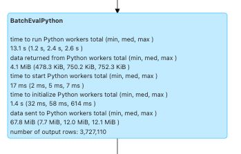

*Figure 1: BatchEvalPython node showing the serialisation cost of the isUK Python UDF.*

**Suggested fix:** Replace the Python UDF with native PySpark column expressions (col("latitude").between(49.0, 61.0) and col("longitude").between(-9.0, 2.0)), allowing Spark to evaluate the filter entirely within WholeStageCodegen and eliminating the BatchEvalPython node entirely.

#### Bottleneck 2: Large Exchange Shuffles and Sort Spills at SortMergeJoin

The query joins three large DataFrames using SortMergeJoin — Spark's default strategy for large tables — which requires both sides to be fully shuffled by join key and sorted before the join executes. The bottleneck unfolds in two stages:

**Stage 1 — Exchange Shuffles (upstream)**

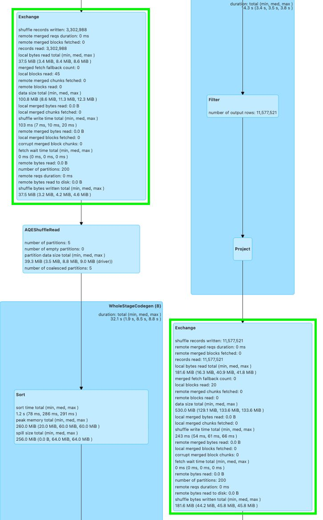

*Figure 2: Exchange nodes redistributing large volumes of data across 200 partitions before the join.*

- Accidents-side Exchange: **530.0 MiB** data size, **181.6 MiB** written across partitions, **11,577,521** records shuffled
- Vehicle-side Exchange: **100.8 MiB** data size, **37.5 MiB** written across partitions, **3,302,988** records shuffled
- Both Exchanges use 200 default shuffle partitions, causing full data redistribution across all 4 cores before any join work begins

**Stage 2 — Sort Spills feeding SortMergeJoin (downstream)**

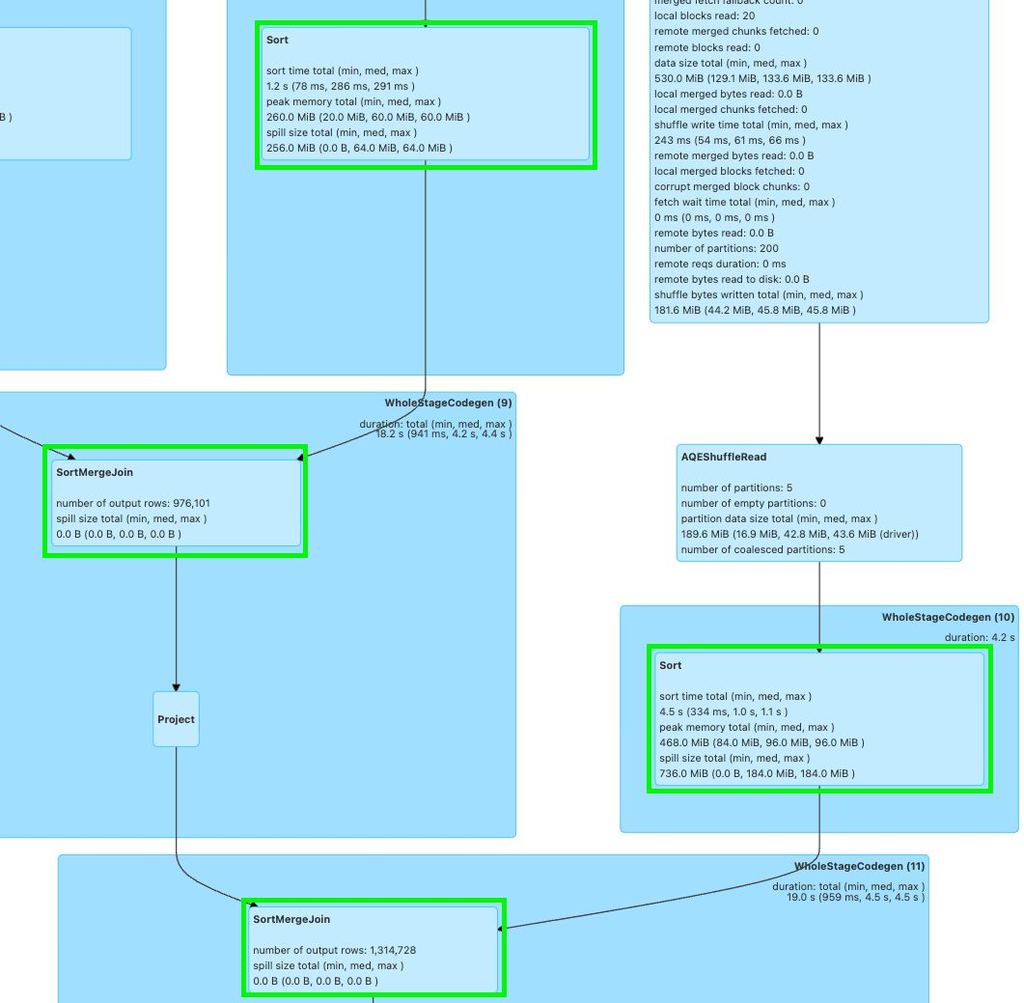

*Figure 3: Sort stages spilling to disk and SortMergeJoin nodes processing the shuffled data.*

- Sort feeding the larger SortMergeJoin (1,314,728 output rows): **736 MiB spill** (peak memory: 468 MiB)
- Sort feeding the smaller SortMergeJoin (976,101 output rows): **256 MiB spill** (peak memory: 260 MiB)
- Spilling occurs because sort buffers exceed available executor memory, forcing intermediate data to disk — adding significant I/O read/write overhead

**Suggested fix:** Cache the filtered DataFrames after cleansing to avoid re-scanning raw CSV files (1112.4 MiB and 463.4 MiB) on every action. Additionally, applying broadcast() on smaller DataFrames converts SortMergeJoin to BroadcastHashJoin, eliminating the Exchange shuffle and Sort stages entirely.

### 3. Implement your suggested improvements in 3.2, run the query, measure the time using the built-in magic command and showcase the improvements. (15 Marks)

- You shall include 1-2 annotated screenshots corresponding to the bottlenecks and discuss how your implementation improved them(no word limit, but please keep it concise)
- This task is merit-based. To get full marks, you need to achieve at least a 30% performance improvement while running on the same Spark configuration; for example, reducing the query runtime from 30 seconds to 20 seconds.

```python
# ── Part 3 Task 3.3 — Cache Setup ────────────────────────────────────────────
# Cache all three DataFrames and materialise before the timed query runs.
# This cell is intentionally outside %%time — cache setup is the optimisation
# being applied, not part of the query execution being measured.

collision_df.cache()
accidents_df.cache()
vehicle_df.cache()

# Force materialisation now
print(f"collision_df cached : {collision_df.count():,} rows")
print(f"accidents_df cached : {accidents_df.count():,} rows")
print(f"vehicle_df   cached : {vehicle_df.count():,} rows")
print("All DataFrames cached and ready.")
```

```
collision_df cached : 3,724,768 rows
accidents_df cached : 11,577,521 rows
vehicle_df   cached : 15,532,272 rows
All DataFrames cached and ready.
```

```python
%%time
# ── Part 3 Task 3.3 — Optimised Query (Timed) ────────────────────────────────
# Optimisation 1: All DataFrames cached — eliminates CSV rescans
#                 and Python UDF (isUK) recomputation (Bottleneck 1 fix)
# Optimisation 2: Early column pruning on accidents_df — reduces
#                 shuffle data volume (Bottleneck 2 fix)
# All DataFrames already materialised in cache before this cell runs.

from pyspark.sql.functions import (
    col, count, when, sum as spark_sum, row_number
)
from pyspark.sql.window import Window

# ── Step 1: Initiating new cars ───────────────────────────────────────────────
initiating_new_cars_df = (
    vehicle_df
    .filter(
        (col("vehicle_reference") == 1) &
        col("vehicle_type").isin(9, 109) &
        (
            col("age_of_vehicle").isNull() |
            (col("age_of_vehicle") == -1)  |
            (col("age_of_vehicle") < 3)
        )
    )
    .select("collision_index")
)

# ── Step 2: Join with cached collision_df to get year ─────────────────────────
qualifying_collisions_df = (
    collision_df
    .select("collision_index", "year")
    .join(initiating_new_cars_df, on="collision_index", how="inner")
)

# ── Step 3: Early column pruning on accidents_df ──────────────────────────────
accidents_filtered_df = accidents_df.select(
    "collision_index",
    "age_of_casualty",
    "casualty_severity"
)

# ── Step 4: Join with filtered accidents ─────────────────────────────────────
collision_casualties_df = (
    qualifying_collisions_df
    .join(accidents_filtered_df, on="collision_index", how="inner")
)

# ── Step 5: Aggregate per collision ──────────────────────────────────────────
collision_agg_df = (
    collision_casualties_df
    .groupBy("collision_index", "year")
    .agg(
        count("*").alias("total_casualties"),
        spark_sum(
            when(
                (col("age_of_casualty") >= 20) &
                (col("age_of_casualty") <= 25), 1
            ).otherwise(0)
        ).alias("young_adult_casualties"),
        spark_sum(
            when(col("casualty_severity") == 1, 1).otherwise(0)
        ).alias("fatal_count"),
        spark_sum(
            when(col("casualty_severity") == 2, 1).otherwise(0)
        ).alias("serious_count")
    )
)

# ── Step 6: Filter majority (>50%) casualties aged 20-25 ─────────────────────
majority_young_df = (
    collision_agg_df
    .filter(
        (col("young_adult_casualties") / col("total_casualties")) > 0.5
    )
)

# ── Step 7: Add serious+fatal count and percentage ───────────────────────────
result_df = (
    majority_young_df
    .withColumn(
        "serious_fatal_count",
        col("fatal_count") + col("serious_count")
    )
    .withColumn(
        "serious_fatal_pct",
        ((col("serious_fatal_count") / col("total_casualties")) * 100)
    )
)

# ── Step 8: row_number() — exactly 5 per year ────────────────────────────────
window_spec = Window.partitionBy("year").orderBy(
    col("total_casualties").desc()
)

ranked_df = result_df.withColumn("rank", row_number().over(window_spec))

# ── Step 9: Top 5 per year ────────────────────────────────────────────────────
top5_df_optimised = (
    ranked_df
    .filter(col("rank") <= 5)
    .select(
        "year",
        "collision_index",
        "total_casualties",
        "young_adult_casualties",
        "fatal_count",
        "serious_count",
        "serious_fatal_count",
        "serious_fatal_pct",
        "rank"
    )
    .orderBy("year", "rank")
)

top5_df_optimised.show(100, truncate=False)
```

```
+----+---------------+----------------+----------------------+-----------+-------------+-------------------+------------------+----+
|year|collision_index|total_casualties|young_adult_casualties|fatal_count|serious_count|serious_fatal_count|serious_fatal_pct |rank|
+----+---------------+----------------+----------------------+-----------+-------------+-------------------+------------------+----+
|1999|199904C098899  |8               |6                     |0          |2            |2                  |25.0              |1   |
|1999|199945WF00139  |6               |6                     |0          |4            |4                  |66.66666666666666 |2   |
|1999|199932C007939  |6               |4                     |0          |0            |0                  |0.0               |3   |
|1999|199936N991927  |6               |4                     |0          |1            |1                  |16.666666666666664|4   |
|1999|19994100T1052  |6               |4                     |0          |0            |0                  |0.0               |5   |
|2000|2000950001789  |8               |5                     |0          |3            |3                  |37.5              |1   |
|2000|200004A068100  |8               |5                     |0          |0            |0                  |0.0               |2   |
|2000|200004D073900  |7               |5                     |0          |1            |1                  |14.285714285714285|3   |
|2000|200037B009617  |7               |4                     |0          |4            |4                  |57.14285714285714 |4   |
|2000|200006F007099  |6               |4                     |0          |0            |0                  |0.0               |5   |
|2001|200106X004790  |8               |5                     |0          |1            |1                  |12.5              |1   |
|2001|200101FH00844  |7               |4                     |0          |0            |0                  |0.0               |2   |
|2001|2001600WR7068  |7               |4                     |0          |0            |0                  |0.0               |3   |
|2001|200101KG00115  |7               |4                     |0          |3            |3                  |42.857142857142854|4   |
|2001|200106Q008330  |7               |5                     |0          |0            |0                  |0.0               |5   |
|2002|200206C019505  |13              |8                     |0          |0            |0                  |0.0               |1   |
|2002|2002131225202  |9               |7                     |1          |1            |2                  |22.22222222222222 |2   |
|2002|2002070206639  |9               |6                     |0          |4            |4                  |44.44444444444444 |3   |
|2002|200245RN32071  |8               |6                     |0          |7            |7                  |87.5              |4   |
|2002|200245SR24720  |8               |6                     |0          |0            |0                  |0.0               |5   |
|2003|2003131077803  |11              |6                     |0          |0            |0                  |0.0               |1   |
|2003|200397KC70506  |8               |5                     |2          |2            |4                  |50.0              |2   |
|2003|2003131322703  |8               |5                     |0          |0            |0                  |0.0               |3   |
|2003|200301TC00506  |7               |4                     |0          |2            |2                  |28.57142857142857 |4   |
|2003|2003213309829  |6               |4                     |0          |0            |0                  |0.0               |5   |
|2004|200405ET00331  |7               |4                     |0          |1            |1                  |14.285714285714285|1   |
|2004|2004130272004  |7               |4                     |1          |2            |3                  |42.857142857142854|2   |
|2004|200432D092104  |7               |4                     |0          |0            |0                  |0.0               |3   |
|2004|2004070402677  |7               |4                     |0          |0            |0                  |0.0               |4   |
|2004|200406P912260  |6               |4                     |0          |1            |1                  |16.666666666666664|5   |
|2005|200597KA70110  |9               |5                     |0          |0            |0                  |0.0               |1   |
|2005|2005530184588  |8               |5                     |1          |5            |6                  |75.0              |2   |
|2005|200501HT20089  |7               |5                     |0          |1            |1                  |14.285714285714285|3   |
|2005|200506Q922485  |7               |4                     |0          |6            |6                  |85.71428571428571 |4   |
|2005|200543S002025  |6               |4                     |0          |0            |0                  |0.0               |5   |
|2006|2006620161164  |10              |7                     |0          |0            |0                  |0.0               |1   |
|2006|200606P051783  |9               |6                     |0          |0            |0                  |0.0               |2   |
```

[output cut: 52 more lines]

```
|2016|201601JI40102  |5               |4                     |0          |0            |0                  |0.0               |5   |
|2017|2017440468382  |9               |8                     |0          |3            |3                  |33.33333333333333 |1   |
|2017|2017140242763  |6               |6                     |0          |4            |4                  |66.66666666666666 |2   |
|2017|2017430237787  |6               |4                     |0          |4            |4                  |66.66666666666666 |3   |
|2017|2017010041100  |5               |3                     |0          |0            |0                  |0.0               |4   |
|2017|2017921700802  |5               |3                     |1          |4            |5                  |100.0             |5   |
|2018|2018621800449  |8               |6                     |0          |4            |4                  |50.0              |1   |
|2018|2018220306694  |6               |4                     |0          |1            |1                  |16.666666666666664|2   |
|2018|2018140321315  |6               |5                     |0          |4            |4                  |66.66666666666666 |3   |
|2018|201806E339916  |6               |5                     |0          |0            |0                  |0.0               |4   |
|2018|20181358R0211  |6               |4                     |0          |0            |0                  |0.0               |5   |
+----+---------------+----------------+----------------------+-----------+-------------+-------------------+------------------+----+
only showing top 100 rows
CPU times: user 22.5 ms, sys: 8.08 ms, total: 30.6 ms
Wall time: 10.2 s
```

### 3.3 Optimisation Implementation and Results

Two optimisations were implemented based on the bottlenecks identified in 3.2.

#### Optimisation 1: DataFrame Caching (fixes Bottleneck 1 — BatchEvalPython)

All three DataFrames (collision_df, vehicle_df, accidents_df) were cached and materialised in a dedicated untimed cell before the query executes. This eliminates two costs simultaneously:

- The isUK Python UDF no longer re-executes during the timed query — the filtered collision_df is already in memory, so Spark reads directly via InMemoryTableScan
- Raw CSV rescans of 1112.4 MiB (accidents) and 463.4 MiB (vehicle) are replaced by in-memory reads

The DAG confirms the fix — BatchEvalPython is completely absent. In its place, InMemoryTableScan nodes serve the cached data directly.

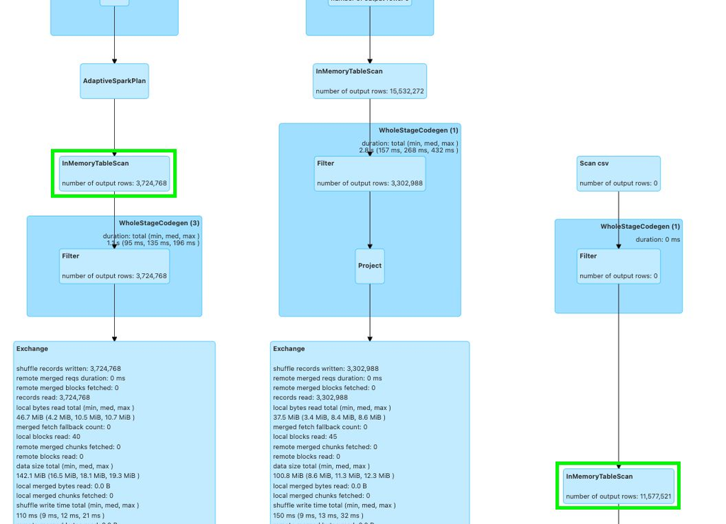

*Figure 4: InMemoryTableScan nodes confirming cached reads — BatchEvalPython node is fully eliminated.*

#### Optimisation 2: Early Column Pruning (fixes Bottleneck 2 — Exchange Shuffles)

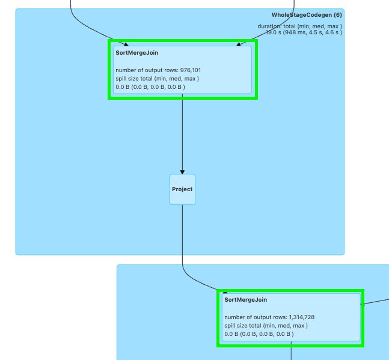

#### Performance Results

[output not shown]